# Forest Fire Prediction

Our client want me to predict the burned area of forest fires using meteorological and other data.  
The data set I have contains the weather information, date, location in the northeast region of Portugal.

> Portugal is highly affected by forest fires. From 1980 to 2005, over 2.7 million ha of forest area (equivalent to the Albania land area) have been destroyed. The 2003 and 2005 fire seasons were especially dramatic, affecting 4.6% and 3.1% of the territory, with 21 and 18 human deaths.  
> -- European-Commission. Forest Fires in Europe. Technical report, Report N-4/6, 2003/2005.

```r
require(data.table) || install.packages("data.table", repos='http://cran.us.r-project.org')  # rename
require(dplyr) || install.packages("dplyr", repos='http://cran.us.r-project.org')  # data wrangling
require(ggplot2) || install.packages("ggplot2", repos='http://cran.us.r-project.org')  # visualization
require(gridExtra) || install.packages("gridExtra", repos='http://cran.us.r-project.org')  # arrange visualization
require('corrgram') || install.packages("corrgram", repos='http://cran.r-project.org')   # correlation map
require(kernlab) || install.packages("kernlab", repos='http://cran.us.r-project.org')
require(caret) || install.packages("caret", repos='http://cran.us.r-project.org')
require(e1071) || install.packages("e1071", repos='http://cran.us.r-project.org')
require(MASS) || install.packages("MASS", repos='http://cran.us.r-project.org')  # linear discriminant analysis
require(Amelia) || install.packages("Amelia", repos='http://cran.us.r-project.org')  # miss map
require(neuralnet) || install.packages("neuralnet", repos='http://cran.us.r-project.org')

options(repr.plot.width=6, repr.plot.height=6)
```

### Read in the Data Set

You can download the [Data Set](https://archive.ics.uci.edu/ml/datasets/Forest+Fires) by clicking the link.

```r
fire <- read.csv("F:/UVA/Spring 2017/StatisticalConsulting/FinalProject/forestfires.csv",
                 header = TRUE, stringsAsFactors = FALSE)
head(fire)
```

| X | Y | month | day | FFMC | DMC | DC | ISI | temp | RH | wind | rain | area |
| --- | --- | --- | --- | --- | --- | --- | --- | --- | --- | --- | --- | --- |
| 7 | 5 | mar | fri | 86.2 | 26.2 | 94.3 | 5.1 | 8.2 | 51 | 6.7 | 0.0 | 0 |
| 7 | 4 | oct | tue | 90.6 | 35.4 | 669.1 | 6.7 | 18.0 | 33 | 0.9 | 0.0 | 0 |
| 7 | 4 | oct | sat | 90.6 | 43.7 | 686.9 | 6.7 | 14.6 | 33 | 1.3 | 0.0 | 0 |
| 8 | 6 | mar | fri | 91.7 | 33.3 | 77.5 | 9.0 | 8.3 | 97 | 4.0 | 0.2 | 0 |
| 8 | 6 | mar | sun | 89.3 | 51.3 | 102.2 | 9.6 | 11.4 | 99 | 1.8 | 0.0 | 0 |
| 8 | 6 | aug | sun | 92.3 | 85.3 | 488.0 | 14.7 | 22.2 | 29 | 5.4 | 0.0 | 0 |

```r
glimpse(fire)
```

```
Observations: 517
Variables: 13
$ X     <int> 7, 7, 7, 8, 8, 8, 8, 8, 8, 7, 7, 7, 6, 6, 6, 6, 5, 8, 6, 6, 6...
$ Y     <int> 5, 4, 4, 6, 6, 6, 6, 6, 6, 5, 5, 5, 5, 5, 5, 5, 5, 5, 4, 4, 4...
$ month <chr> "mar", "oct", "oct", "mar", "mar", "aug", "aug", "aug", "sep"...
$ day   <chr> "fri", "tue", "sat", "fri", "sun", "sun", "mon", "mon", "tue"...
$ FFMC  <dbl> 86.2, 90.6, 90.6, 91.7, 89.3, 92.3, 92.3, 91.5, 91.0, 92.5, 9...
$ DMC   <dbl> 26.2, 35.4, 43.7, 33.3, 51.3, 85.3, 88.9, 145.4, 129.5, 88.0,...
$ DC    <dbl> 94.3, 669.1, 686.9, 77.5, 102.2, 488.0, 495.6, 608.2, 692.6, ...
$ ISI   <dbl> 5.1, 6.7, 6.7, 9.0, 9.6, 14.7, 8.5, 10.7, 7.0, 7.1, 7.1, 22.6...
$ temp  <dbl> 8.2, 18.0, 14.6, 8.3, 11.4, 22.2, 24.1, 8.0, 13.1, 22.8, 17.8...
$ RH    <int> 51, 33, 33, 97, 99, 29, 27, 86, 63, 40, 51, 38, 72, 42, 21, 4...
$ wind  <dbl> 6.7, 0.9, 1.3, 4.0, 1.8, 5.4, 3.1, 2.2, 5.4, 4.0, 7.2, 4.0, 6...
$ rain  <dbl> 0.0, 0.0, 0.0, 0.2, 0.0, 0.0, 0.0, 0.0, 0.0, 0.0, 0.0, 0.0, 0...
$ area  <dbl> 0, 0, 0, 0, 0, 0, 0, 0, 0, 0, 0, 0, 0, 0, 0, 0, 0, 0, 0, 0, 0...
```

```r
# Any missing value?
sapply(fire,function(x) sum(is.na(x)))
##  No missing value
```

**X**

0

**Y**

0

**month**

0

**day**

0

**FFMC**

0

**DMC**

0

**DC**

0

**ISI**

0

**temp**

0

**RH**

0

**wind**

0

**rain**

0

**area**

0

```r
fire_new <- fire
```

### Understanding the Data Set

The data set has 517 observations and 13 variables. Most of the variables are numeric. Only a few are categorical variables such as day and month.

#### Variables

##### Meteorological information

- **temp** - temperature in Celsius degrees
- **RH** - relative humidity in %
- **wind** - wind speed in km/h
- **rain** - outside rain in mm/m2

##### Time

- **month** - month of the year: 'jan' to 'dec'
- **day** - day of the week: 'mon' to 'sun'

```r
unique(fire_new$month)
unique(fire_new$day)
```

1. 'mar'

2. 'oct'

3. 'aug'

4. 'sep'

5. 'apr'

6. 'jun'

7. 'jul'

8. 'feb'

9. 'jan'

10. 'dec'

11. 'may'

12. 'nov'

1. 'fri'

2. 'tue'

3. 'sat'

4. 'sun'

5. 'mon'

6. 'wed'

7. 'thu'

##### Location and Burned Area

<font color=red>You can get the map of [Montesinho natural park](http://www.montesinho.com/files/mapamontesinho.pdf) here. </font>

- **X** - x-axis spatial coordinate within the Montesinho park map: 1 to 9
- **Y** - y-axis spatial coordinate within the Montesinho park map: 2 to 9
- **area** - the burned area of the forest (in ha)

### Data Recoding

#### Transforming Month: "jan" => 1

```r
fire_new$month[fire_new$month == "jan"] <- 1
fire_new$month[fire_new$month == "feb"] <- 2
fire_new$month[fire_new$month == "mar"] <- 3
fire_new$month[fire_new$month == "apr"] <- 4
fire_new$month[fire_new$month == "may"] <- 5
fire_new$month[fire_new$month == "jun"] <- 6
fire_new$month[fire_new$month == "jul"] <- 7
fire_new$month[fire_new$month == "aug"] <- 8
fire_new$month[fire_new$month == "sep"] <- 9
fire_new$month[fire_new$month == "oct"] <- 10
fire_new$month[fire_new$month == "nov"] <- 11
fire_new$month[fire_new$month == "dec"] <- 12

fire_new$month <- factor(fire_new$month, levels = 1:12 %>% as.character)
```

#### month => season

```r
indx <- setNames( rep(c('winter', 'spring', 'summer',
                   'fall'),each=3), c(12,1:11))

fire_new$Season <- as.factor(unname(indx[as.character(fire_new$month)]))
fire_new$Season  %>% table()
```

```
.
  fall spring summer winter
   188     65    233     31
```

```r
fire_new$Season_n[fire_new$Season == "spring"] <- 1
fire_new$Season_n[fire_new$Season == "summer"] <- 2
fire_new$Season_n[fire_new$Season == "fall"] <- 3
fire_new$Season_n[fire_new$Season == "winter"] <- 4
```

#### Transforming day: "mon" => 1

```r
fire_new$day[fire_new$day == "mon"] <- 1
fire_new$day[fire_new$day == "tue"] <- 2
fire_new$day[fire_new$day == "wed"] <- 3
fire_new$day[fire_new$day == "thu"] <- 4
fire_new$day[fire_new$day == "fri"] <- 5
fire_new$day[fire_new$day == "sat"] <- 6
fire_new$day[fire_new$day == "sun"] <- 7
```

##### Area => Size

```r
## check the number of large/small burned area

fire_new$size[fire_new$area == 0] <- 0
fire_new$size[fire_new$area > 0 & fire_new$area < 5] <- 1
fire_new$size[fire_new$area > 5 & fire_new$area < 50] <- 2
fire_new$size[fire_new$area > 50] <- 3
fire_new$size <- as.factor(fire_new$size)
fire_new$size %>% table()
```

```
.
  0   1   2   3
247 119 127  24
```

##### area => log_area

```r
fire_new$log_area <- log(fire_new$area + 1)
```

#### rain: "rain" => 1, "no-rain" = 0

```r
fire_new$rain_binary <- ifelse(fire_new$rain == 0, 0,1)
```

##### X, Y as factor

```r
fire_new$X <- as.factor(fire_new$X)
fire_new$Y <- as.factor(fire_new$Y)
```

#### location: X, Y

```r
fire_new <- fire_new %>%
    mutate(X_char = X %>% as.character,
           Y_char = Y %>% as.character,
           location = paste(X_char, Y_char, sep = ","))

length(unique(fire_new$location))   # we have 36 unique areas
```

36

##### new variables

```r
fire_new$human[fire_new$month == 1 |fire_new$month == 2 |fire_new$month == 3 |fire_new$month == 4 |fire_new$month == 5|fire_new$month == 6|fire_new$month == 10|fire_new$month == 11 |fire_new$month == 12] <- 0
fire_new$human[fire_new$month == 7 |fire_new$month == 8 |fire_new$month == 9] <- 1
```

```r
table(fire_new$human)
```

```
  0   1
129 388
```

##### Subset

```r
fire_small <- subset(fire_new, fire_new$area <= 5)
fire_large <- subset(fire_new, fire_new$area > 5)
```

### Regression

```r
reg3 <- lm(log_area ~X + Y + Season + day + (FFMC + DMC + DC + ISI)^2 + temp + RH + wind + rain + I(wind^2) + human, data = fire_large); summary(reg3)
```

```
Call:
lm(formula = log_area ~ X + Y + Season + day + (FFMC + DMC +
    DC + ISI)^2 + temp + RH + wind + rain + I(wind^2) + human,
    data = fire_large)

Residuals:
    Min      1Q  Median      3Q     Max
-2.0482 -0.6168 -0.1141  0.5429  2.9255

Coefficients:
               Estimate Std. Error t value Pr(>|t|)
(Intercept)  -6.462e+00  8.638e+00  -0.748  0.45601
X2           -4.695e-01  4.012e-01  -1.170  0.24439
X3           -5.768e-01  4.748e-01  -1.215  0.22699
X4            1.632e-01  3.508e-01   0.465  0.64256
X5           -3.362e-01  6.019e-01  -0.559  0.57754
X6            3.195e-01  3.705e-01   0.862  0.39033
X7            8.848e-02  4.121e-01   0.215  0.83040
X8            2.620e-01  5.318e-01   0.493  0.62327
X9            6.771e-01  6.348e-01   1.067  0.28844
Y3           -1.171e+00  5.151e-01  -2.274  0.02486 *
Y4           -9.120e-01  4.615e-01  -1.976  0.05059 .
Y5           -1.005e+00  4.540e-01  -2.215  0.02881 *
Y6           -1.000e+00  6.348e-01  -1.576  0.11791
Y8            7.388e-01  1.278e+00   0.578  0.56441
Seasonspring -1.842e+00  9.973e-01  -1.847  0.06742 .
Seasonsummer -9.935e-01  3.650e-01  -2.722  0.00753 **
Seasonwinter -1.593e+00  1.097e+00  -1.453  0.14906
day2         -2.121e-01  3.613e-01  -0.587  0.55839
day3         -1.996e-01  3.901e-01  -0.512  0.60989
day4         -2.406e-01  3.832e-01  -0.628  0.53130
day5         -2.578e-01  3.589e-01  -0.718  0.47401
day6          1.247e-01  3.435e-01   0.363  0.71734
day7          9.776e-02  3.404e-01   0.287  0.77448
FFMC          1.382e-01  1.075e-01   1.286  0.20125
DMC          -2.306e-01  1.161e-01  -1.985  0.04956 *
DC            3.802e-02  1.978e-02   1.922  0.05718 .
ISI           1.100e+00  1.099e+00   1.001  0.31879
temp          1.241e-02  3.683e-02   0.337  0.73675
RH           -5.891e-03  1.008e-02  -0.584  0.56009
wind          2.804e-01  2.348e-01   1.194  0.23497
rain         -9.967e-02  1.799e-01  -0.554  0.58068
I(wind^2)    -1.444e-02  2.574e-02  -0.561  0.57588
human         6.543e-01  4.708e-01   1.390  0.16735
FFMC:DMC      2.733e-03  1.294e-03   2.112  0.03691 *
FFMC:DC      -4.932e-04  2.421e-04  -2.037  0.04401 *
FFMC:ISI     -1.415e-02  1.200e-02  -1.179  0.24081
DMC:DC       -1.057e-05  1.340e-05  -0.789  0.43176
DMC:ISI      -7.576e-04  7.721e-04  -0.981  0.32862
DC:ISI        4.374e-04  2.753e-04   1.589  0.11488
---
Signif. codes:  0 '***' 0.001 '**' 0.01 '*' 0.05 '.' 0.1 ' ' 1

Residual standard error: 1.001 on 112 degrees of freedom
Multiple R-squared:  0.2803,	Adjusted R-squared:  0.03608
F-statistic: 1.148 on 38 and 112 DF,  p-value: 0.2855
```

```r
reg4<- step(reg3, direction = "backward")
```

```
Start:  AIC=33.09
log_area ~ X + Y + Season + day + (FFMC + DMC + DC + ISI)^2 +
    temp + RH + wind + rain + I(wind^2) + human

            Df Sum of Sq    RSS    AIC
- day        6    3.1116 115.27 25.224
- X          8    9.6210 121.78 29.519
- temp       1    0.1137 112.27 31.245
- rain       1    0.3073 112.46 31.505
- I(wind^2)  1    0.3152 112.47 31.516
- RH         1    0.3421 112.50 31.552
- DMC:DC     1    0.6234 112.78 31.929
- DMC:ISI    1    0.9640 113.12 32.384
- FFMC:ISI   1    1.3924 113.55 32.955
- wind       1    1.4278 113.58 33.002
<none>                   112.15 33.092
- human      1    1.9342 114.09 33.674
- Y          5    8.5907 120.75 34.236
- DC:ISI     1    2.5285 114.68 34.458
- FFMC:DC    1    4.1548 116.31 36.585
- FFMC:DMC   1    4.4666 116.62 36.989
- Season     3    9.2415 121.40 39.048

Step:  AIC=25.22
log_area ~ X + Y + Season + FFMC + DMC + DC + ISI + temp + RH +
    wind + rain + I(wind^2) + human + FFMC:DMC + FFMC:DC + FFMC:ISI +
    DMC:DC + DMC:ISI + DC:ISI

            Df Sum of Sq    RSS    AIC
- X          8    9.1889 124.45 20.806
- I(wind^2)  1    0.1301 115.40 23.394
- RH         1    0.1874 115.45 23.469
- rain       1    0.4274 115.69 23.783
- DMC:DC     1    0.4297 115.69 23.786
- temp       1    0.4517 115.72 23.815
- wind       1    1.0355 116.30 24.575
- DMC:ISI    1    1.4680 116.73 25.135
<none>                   115.27 25.224
- human      1    1.9910 117.26 25.810
- FFMC:ISI   1    2.1673 117.43 26.037
```

[output cut: 134 more lines]

```
- Season    3   10.3153 143.39 16.193

Step:  AIC=10.83
log_area ~ Season + FFMC + DMC + DC + ISI + RH + wind + FFMC:DMC +
    FFMC:DC + FFMC:ISI + DC:ISI

           Df Sum of Sq    RSS    AIC
<none>                  134.77 10.834
- FFMC:ISI  1    2.4945 137.27 11.603
- DC:ISI    1    2.8704 137.64 12.016
- RH        1    3.0185 137.79 12.178
- FFMC:DMC  1    3.4484 138.22 12.649
- FFMC:DC   1    3.4839 138.26 12.688
- wind      1    4.9113 139.69 14.239
- Season    3   13.3243 148.10 19.070
```

```r
summary(reg4)
```

```
Call:
lm(formula = log_area ~ Season + FFMC + DMC + DC + ISI + RH +
    wind + FFMC:DMC + FFMC:DC + FFMC:ISI + DC:ISI, data = fire_large)

Residuals:
    Min      1Q  Median      3Q     Max
-1.9314 -0.7017 -0.1604  0.5267  3.4896

Coefficients:
               Estimate Std. Error t value Pr(>|t|)
(Intercept)  -5.4902489  7.2297015  -0.759 0.448917
Seasonspring -2.4158523  0.7310874  -3.304 0.001215 **
Seasonsummer -0.6097312  0.2974833  -2.050 0.042308 *
Seasonwinter -2.5095840  0.7038953  -3.565 0.000501 ***
FFMC          0.1368642  0.0879837   1.556 0.122119
DMC          -0.1522335  0.0835174  -1.823 0.070518 .
DC            0.0242001  0.0148871   1.626 0.106338
ISI           1.2977320  0.9486257   1.368 0.173548
RH           -0.0108653  0.0062028  -1.752 0.082070 .
wind          0.1210347  0.0541696   2.234 0.027079 *
FFMC:DMC      0.0017182  0.0009177   1.872 0.063303 .
FFMC:DC      -0.0003347  0.0001779  -1.882 0.061973 .
FFMC:ISI     -0.0165660  0.0104032  -1.592 0.113602
DC:ISI        0.0003295  0.0001929   1.708 0.089872 .
---
Signif. codes:  0 '***' 0.001 '**' 0.01 '*' 0.05 '.' 0.1 ' ' 1

Residual standard error: 0.9918 on 137 degrees of freedom
Multiple R-squared:  0.1351,	Adjusted R-squared:  0.05304
F-statistic: 1.646 on 13 and 137 DF,  p-value: 0.07976
```

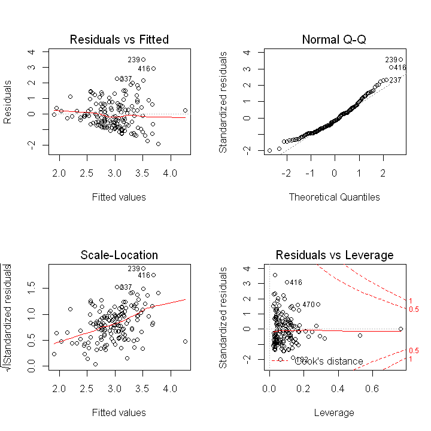

```r
par(mfrow=c(2,2))
plot(reg4)
```